# ECE 438: Digital Signal Processing with Applications Lab 3: Frequency Analysis Date: Section:

| Name | Signature | Time spent outside lab |
| --- | --- | --- |
| Jake Stulgate [100%] |  | 1hr |
| Student Name #2 [---%] |  |  |

|  | Below expectations | Lacks in some respect | Meets all expectations |
| --- | --- | --- | --- |
| **Completeness of the report** |  |  | x |
| **Organization of the report** |  |  | x |
| **Quality of figures**: *Correctly labeled with title, x-axis, y-axis, and name(s)* |  |  | x |
| **Ability to compute Fourier series expansion and synthesize periodic signals using the expansion in Simulink (26 pts)**: *Derivation and sketch, plots of synthesized signals, questions* |  |  | x |
| **Understanding of modulator and CT system analysis (26 pts)**: *Output plots, questions* |  |  | x |
| **Implementation of DTFT (21 pts)**: *Python function, DTFT’s magnitude and phase plots* |  |  | x |
| **DT system analysis (27 pts)**: *Exercises in 5.2, completed block diagram, table of measurements, impulse and frequency response* |  |  | x |

```python
import numpy as np
import matplotlib.pyplot as plt
```

```python
# make sure the plot is displayed in this notebook
%matplotlib inline
# specify the size of the plot
plt.rcParams['figure.figsize'] = (16, 6)

# for auto-reloading extenrnal modules
%load_ext autoreload
%autoreload 2
```

### Exercise 2.1

**1. For each of these two signals, do the following on a blank sheet of paper (or type the equations in the Markdown cell if you are familiar with LaTex):**

- **Compute the Fourier series expansion in the form**

\begin{equation} s(t)=a_0+\sum_{k=1}^\infty A_k\sin(2\pi kf_0t+\theta_k) \end{equation}

where $f_0=\frac{1}{T_0}$.

```
**Hint :**You may want to use one of the following references:

Sec. 4.1 of “Digital Signal Processing”, by Proakis and Manolakis, 1996;

Sec. 4.2 of “Signals and Systems”, by A. Oppenheim and A. Willsky, 1983;

Sec. 3.3 of “Signals and Systems”, A. Oppenheim and A. Willsky, 1997.

Note that in the expression above, the function in the summation is $\sin(2\pi kf_0 t + \theta k )$, rather than a complex sinusoid. The formulas in the above references must be modified to accommodate this. You can compute the cos/sin version of the Fourier series, then convert the coefficients.
```

**2. Write code to approximate the two signals using the Fourier series expansion above. Use 200 (instead of infinite number of) Sine waves. Then, plot these two signals.**

```python
#startup stuff and functions
num_terms = 200
t = np.linspace(0, 1, 1000)

def rect(t):
    return np.where(np.abs(t) < 0.5, 1, 0)

# S1: s_1(t) = rect(t - 1/2)
def s1(t):
    return rect(t - 0.5)

# S2: s_2(t) = rect(2t) - 1/2
def s2(t):
    return rect(2 * t) - 0.5


def fseries(t, num_terms, f_0):
    a_0 = 0.5  # For a symmetric rect function, the DC component (a_0) is 0.5
    s_t = a_0 * np.ones_like(t)

    for k in range(1, num_terms + 1):
        # The Fourier coefficients for a rect function are A_k = 2/(k*pi) for odd k
        if k % 2 == 1:  # Only use odd terms (1, 3, 5,...)
            s_t += (2 / (k * np.pi)) * np.sin(2 * np.pi * k * f_0 * t)

    return s_t
```

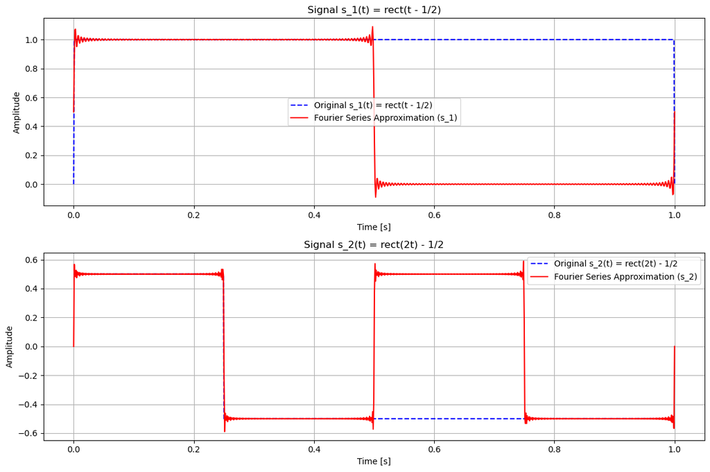

```python
f_0_s1 = 1  # Base frequency for s_1(t)
s1a = fseries(t, num_terms, f_0_s1)

f_0_s2 = 2  # Base frequency for s_2(t)
s2a = fseries(t, num_terms, f_0_s2) - 0.5


plt.figure(figsize=(12, 8))

### Chatgpt used for plotting code below
# Plot s_1(t)
plt.subplot(2, 1, 1)
plt.plot(t, s1(t), label='Original s_1(t) = rect(t - 1/2)', color='b', linestyle='--')
plt.plot(t, s1a, label='Fourier Series Approximation (s_1)', color='r')
plt.title('Signal s_1(t) = rect(t - 1/2)')
plt.xlabel('Time [s]')
plt.ylabel('Amplitude')
plt.grid(True)
plt.legend()

# Plot s_2(t)
plt.subplot(2, 1, 2)
plt.plot(t, s2(t), label='Original s_2(t) = rect(2t) - 1/2', color='b', linestyle='--')
plt.plot(t, s2a, label='Fourier Series Approximation (s_2)', color='r')
plt.title('Signal s_2(t) = rect(2t) - 1/2')
plt.xlabel('Time [s]')
plt.ylabel('Amplitude')
plt.grid(True)
plt.legend()

plt.tight_layout()
plt.show()
```

### Exercise 4.1

**1. Hand in plots of the Spectrum Analyzer output for each of the three synthesized waveforms.**

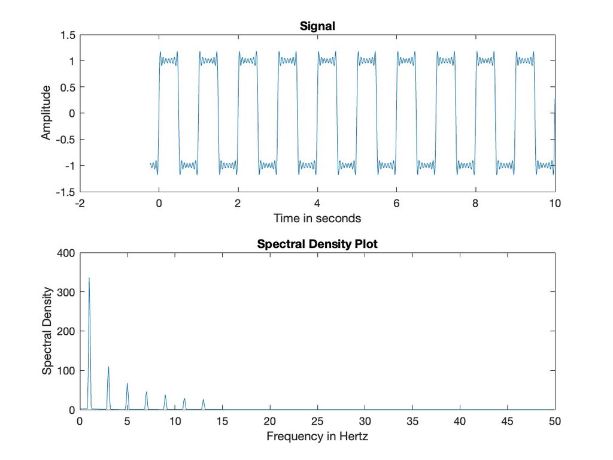

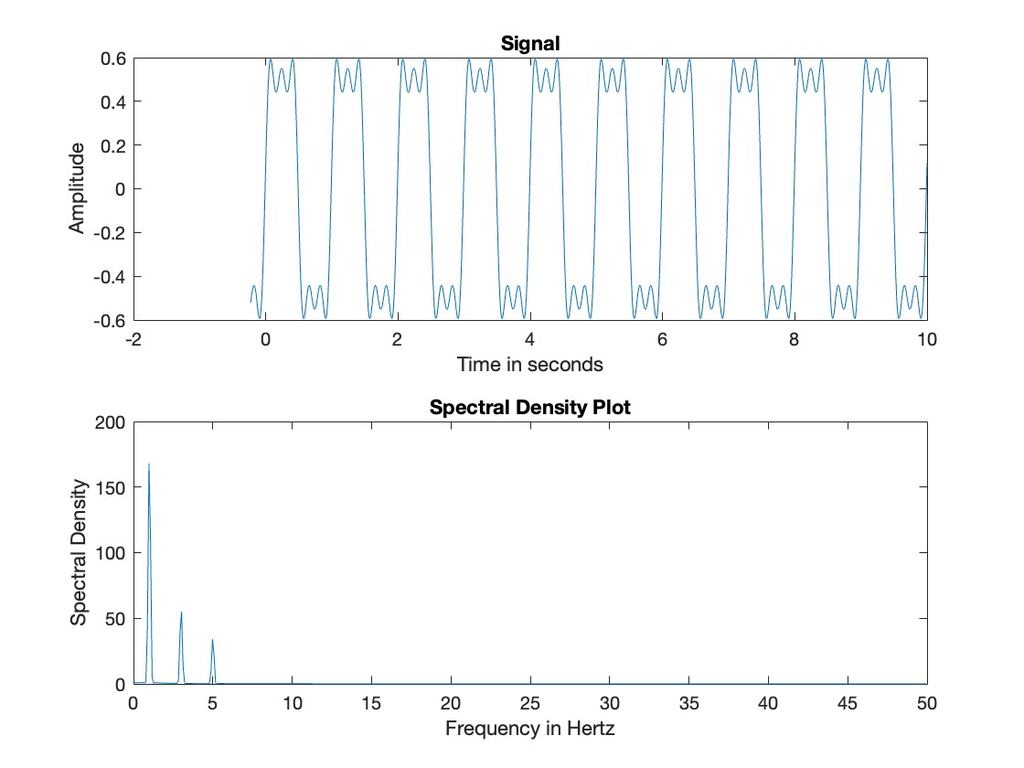

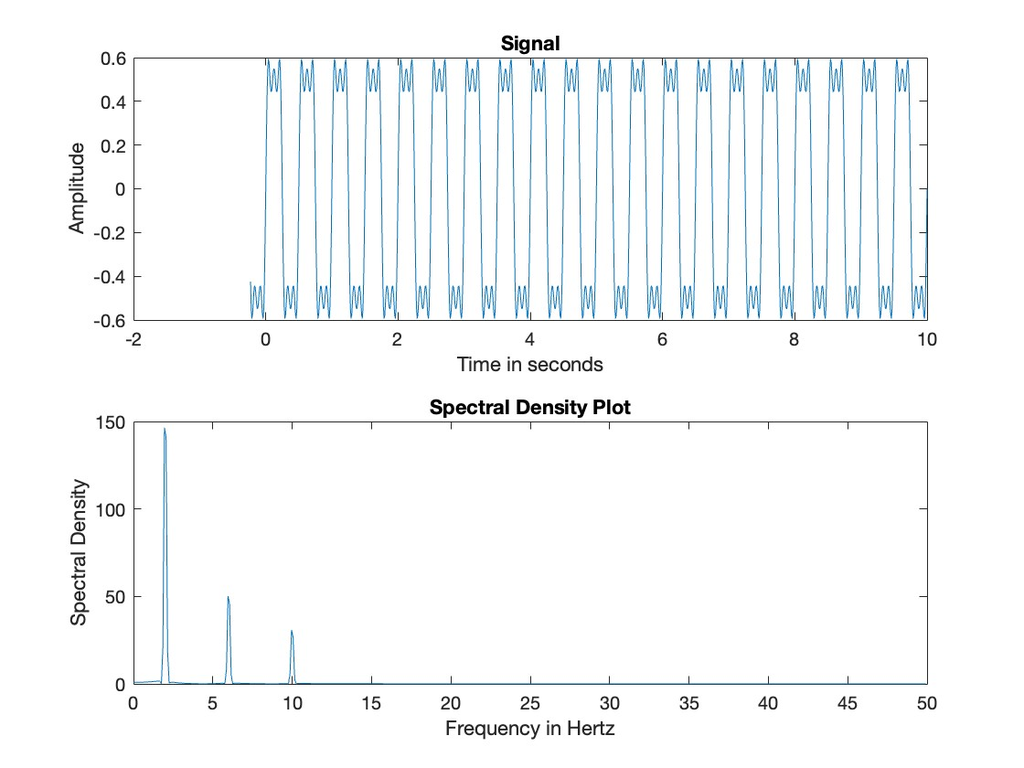

**2. For each case in Q1, comment on how the synthesized waveform differs from the desired signal,and on the structure of the spectral density.**

### Exercise 4.2

**1. Hand in plots of the output of the *Spectrum Analyzer* for each signal.**

(Signal 1)

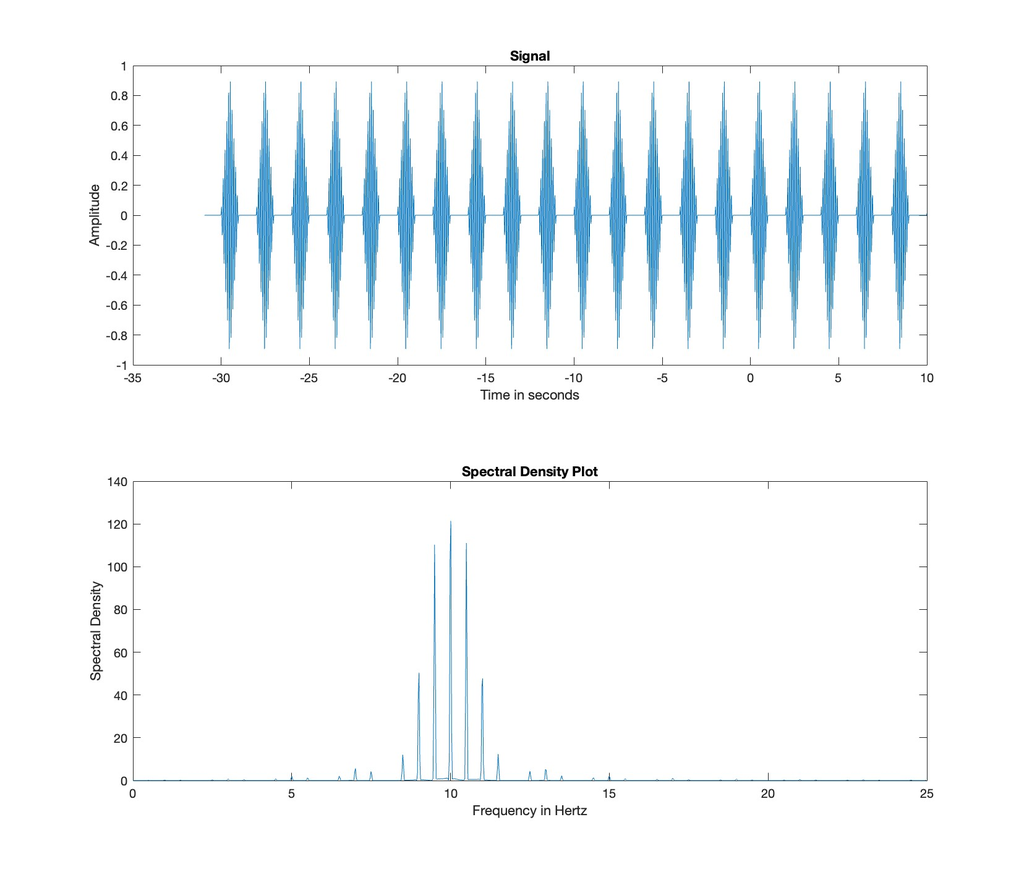

(Signal 2)

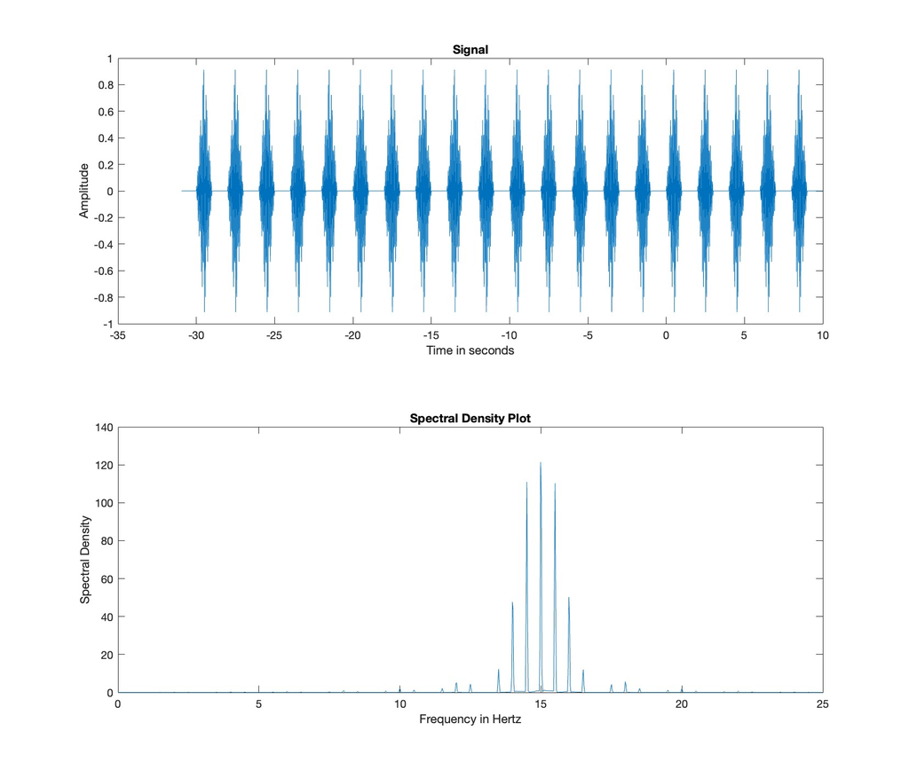

(Signal 3)

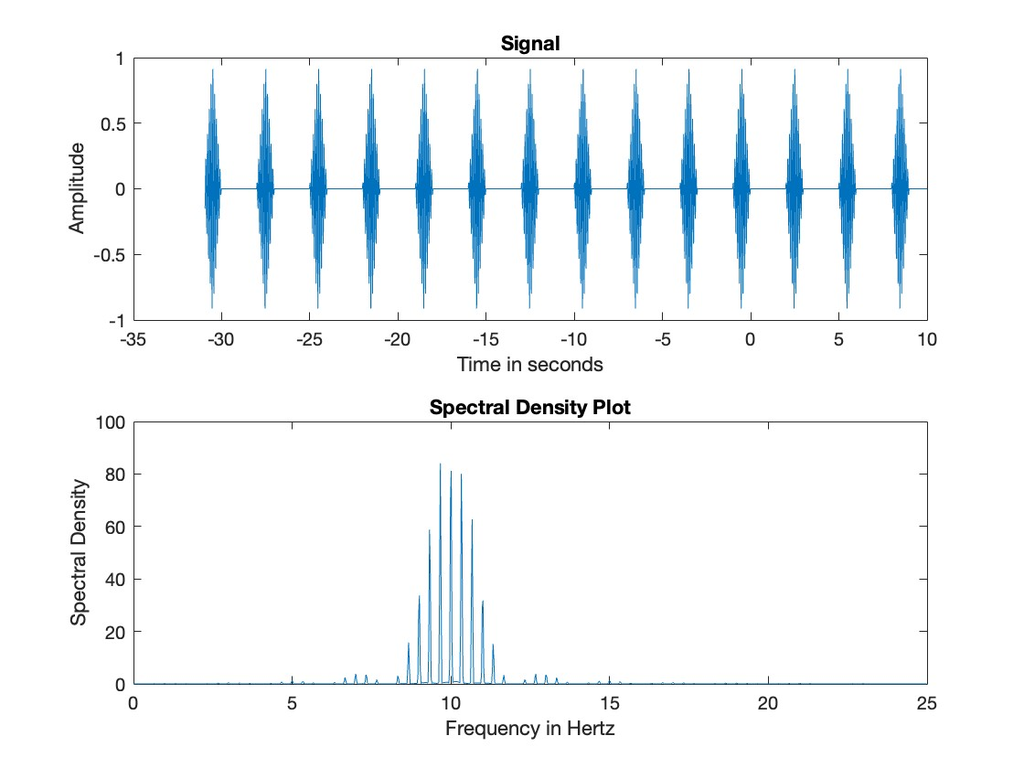

(Signal 4)

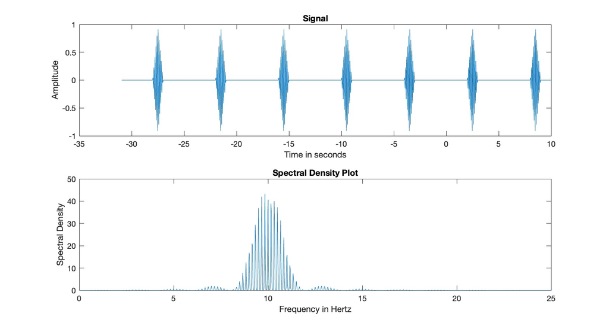

**2. What effect does changing the modulating frequency have on the spectral density?**

It makes the spectral density peak at that frequency.

**3. Why does the spectrum have a comb structure and what is the spectral distance between impulses? Why?**

**4. What would happen to the spectral density if the period of the triangle pulse were to increase toward infinity? (in the limit)**

The entire chart would be zero.

### Exercise 4.3

**1. Hand in the printout of the output of the Network Analyzer (magnitude and phase of the frequency response, and the impulse response).**

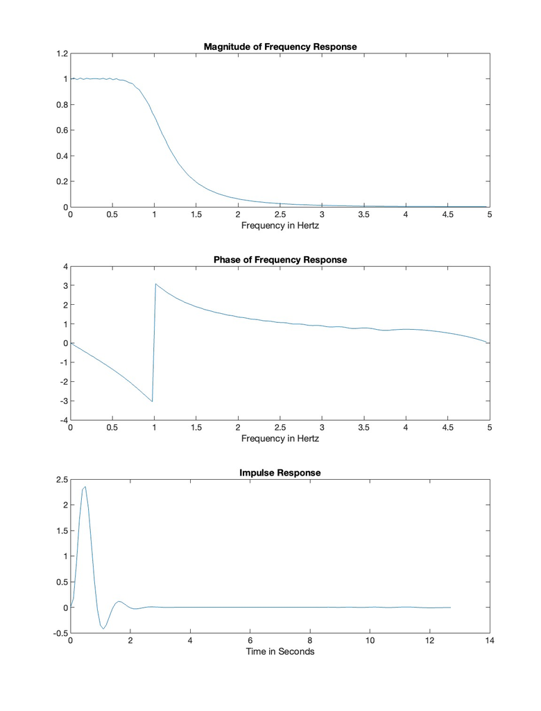

**2. Hand in the plot of the impulse response obtained using a unit step.**

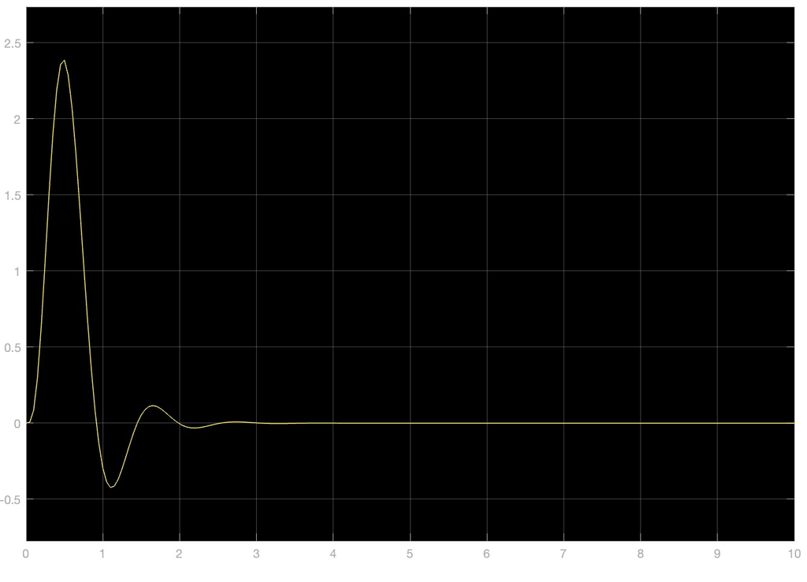

**3. What are the advantages and disadvantages of each method?**

Clearly, the unit step method is very simple, but it also gives a simple analysis. The Network analyzer gives much more information, but is less intuitive.

### Exercise 5.1

**1. Complete the follwing function that computes the DTFT of a discrete-time signal.**

```
def DTFT(x,n0,w):
    """
    This function computes the DTFT of a discrete-time signal.

    Parameters
    ---
    x: the discrete-time signal
    n0: time index corresponding to the 1st element of the x vector
    w: frequencies

    Returns
    ---
    X: the computed DTFT
    """
    pass
```

**Note that if `x` is a vector of length $N$, then its DTFT is computed by**

\begin{equation} X(\omega)=\sum_{n=0}^{N-1}x[n]e^{-jw(n+n0)} \end{equation}

**where $w$ is a vector that contains the frequencies from $-\pi$ to $\pi$.**

**Hint:** In Python, `1j` is defined as $\sqrt{-1}$. Use `np.exp(x)` to calculate $e^x$.

```python
def DTFT(x,n0,w):
    """
    This function computes the DTFT of a discrete-time signal.

    Parameters
    ---
    x: the discrete-time signal
    n0: time index corresponding to the 1st element of the x vector
    w: frequencies

    Returns
    ---
    X: the computed DTFT
    """
    N = len(x)
    X = np.zeros_like(w, dtype=complex)  # starts with complex numbers

    for k, omega in enumerate(w):
        # Adding the values for the current frequency
        for n in range(N):
            X[k] += x[n] * np.exp(-1j * omega * (n + n0))

    return X
```

**2. For the following signals**

- $x[n]=\delta[n]$
- $x[n]=\delta[n-5]$
- $x[n]=(0.5)^nu[n]$

**use your DTFT function to compute $X(\omega)$, and plots its magnitude and phase.**

**Hint**: Use `np.power(a,b)` to calculate $a^b$. Use `np.abs()` and `np.angle()` to compute the magnitude and phase.

```python
def unit_step(n):
    return np.where(n >= 0, 1, 0)

def plot_dtft_magnitude_phase(X, w, signal_name):
    # magnitude
    plt.figure(figsize=(10, 4))

    plt.subplot(1, 2, 1)
    plt.plot(w, np.abs(X))
    plt.title(f'Magnitude of DTFT: {signal_name}')
    plt.xlabel('Frequency (rad/sample)')
    plt.ylabel('|X(w)|')
    plt.grid(True)

    # phase
    plt.subplot(1, 2, 2)
    plt.plot(w, np.angle(X))
    plt.title(f'Phase of DTFT: {signal_name}')
    plt.xlabel('Frequency (rad/sample)')
    plt.ylabel('Phase (radians)')
    plt.grid(True)

    plt.tight_layout()
    plt.show()
```

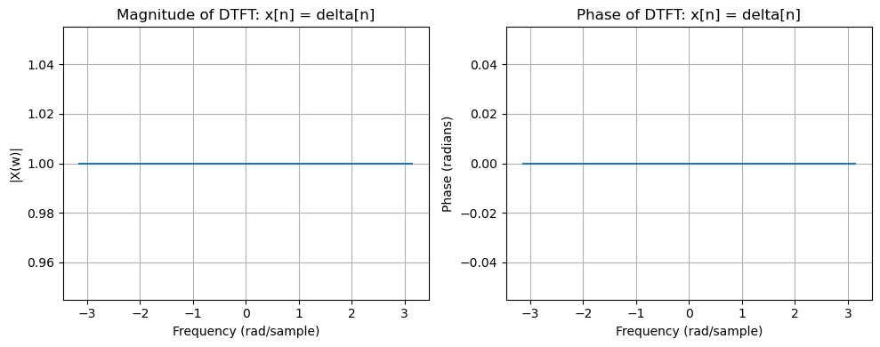

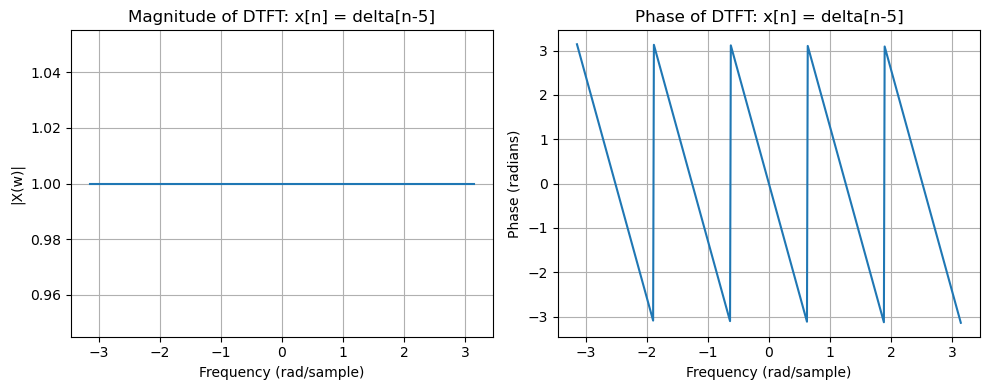

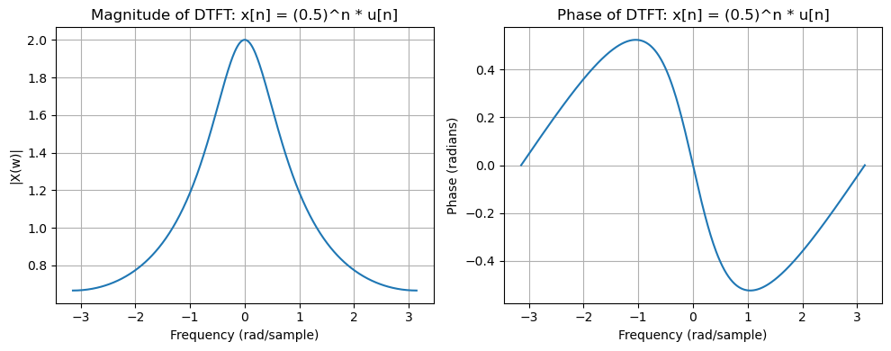

```python
# -pi to pi
w = np.linspace(-np.pi, np.pi, 500)

# 1
x1 = [1]
n0_1 = 0  # index of the first element
X1 = DTFT(x1, n0_1, w)
plot_dtft_magnitude_phase(X1, w, "x[n] = delta[n]")

# 2
x2 = [0, 0, 0, 0, 0, 1]  # impulse delayed by 5
n0_2 = 0
X2 = DTFT(x2, n0_2, w)
plot_dtft_magnitude_phase(X2, w, "x[n] = delta[n-5]")

# 3
n = np.arange(0, 50)
x3 = np.power(0.5, n) * unit_step(n) # signal
n0_3 = 0
X3 = DTFT(x3, n0_3, w)
plot_dtft_magnitude_phase(X3, w, "x[n] = (0.5)^n * u[n]")
```